## DNSC 6279 Spring 2019 Assignment 2

### Group 6 -- Yixuan Huang, Ada Li, Xinyu Wang, Jingsi Wu

In this assignment we will use the data created in assignment 1 to build a logistic regression classifier to predict whether a shopper will become a repeat shopper.

Before beginning the steps below, check the key from assignment 1 to ensure your datasets are correct. Load the labeled training data and the unlabeled test data into a Python or R session. Both datasets must include the three new columns created in assignment 1. The unlabeled test data will now be referred to as the “score” dataset.

```python
import pandas as pd
import numpy as np
# data result from Assignment 1
train_df = pd.read_csv('new_train.csv')
score_df = pd.read_csv('new_test.csv')
```

To begin the labeled training data should have 160057 rows and 14 columns. The score data should have 151484 rows and 13 columns.

```python
train_df.shape
```

```
(160057, 14)
```

```python
score_df.shape
```

```
(151484, 13)
```

### Prepare Data

The following steps can be completed using any packages you choose.

● Recode the target variable, repeater, such that t=1 and f=0.

```python
train_df.repeater = train_df.repeater.map({'t': 1, 'f': 0})
train_df.head()
```

|  | id | category | company | brand | offer | chain | market | repeater | offerdate | quantity | offervalue | mean_quantity | mean_amount | purchased |
| --- | --- | --- | --- | --- | --- | --- | --- | --- | --- | --- | --- | --- | --- | --- |
| 0 | 91452911 | 3203 | 106414464 | 13474 | 1197502 | 3 | 2 | 0 | 2013-04-04 | 1 | 0.75 | 0.0 | 0.0000 | 0 |
| 1 | 96915406 | 3203 | 106414464 | 13474 | 1197502 | 14 | 8 | 0 | 2013-03-31 | 1 | 0.75 | 0.0 | 0.0000 | 0 |
| 2 | 97207695 | 2202 | 104460040 | 3718 | 1208251 | 18 | 11 | 0 | 2013-04-28 | 1 | 2.00 | 0.0 | 0.0000 | 0 |
| 3 | 99128004 | 5616 | 104610040 | 15889 | 1204576 | 17 | 4 | 0 | 2013-04-06 | 1 | 1.00 | 1.5 | 3.4175 | 1 |
| 4 | 99549229 | 3203 | 106414464 | 13474 | 1197502 | 88 | 14 | 0 | 2013-03-26 | 1 | 0.75 | 0.0 | 0.0000 | 0 |

● Set any level of the variable `category` that is in the labeled train set but not in the score set to ‘unknown’ in both sets. Set any level of the variable category that is in the score set but not in the labeled train set to ‘unknown’ in both sets.

● Set any level of the variable `brand` that is in the labeled train set but not in the score set to ‘unknown’ in both sets. Set any level of the variable brand that is in the score set but not in the labeled train set to ‘unknown’ in both sets.

● Set any level of the variable `company` that is in the labeled train set but not in the score set to ‘unknown’ in both sets. Set any level of the variable company that is in the score set but not in the labeled train set to ‘unknown’ in both sets.

● Set any level of the variable `offer` that is in the labeled train set but not in the score set to ‘unknown’ in both sets. Set any level of the variable offer that is in the score set but not in the labeled train set to ‘unknown’ in both sets.

```python
for col in ['category','brand','company','offer']:
    intersect = np.intersect1d(train_df[col].unique(), score_df[col].unique())
    train_df[col] = train_df[col].apply(lambda x: x if x in intersect else 'unknown')
    score_df[col] = score_df[col].apply(lambda x: x if x in intersect else 'unknown')
```

```python
train_df.head()
```

|  | id | category | company | brand | offer | chain | market | repeater | offerdate | quantity | offervalue | mean_quantity | mean_amount | purchased |
| --- | --- | --- | --- | --- | --- | --- | --- | --- | --- | --- | --- | --- | --- | --- |
| 0 | 91452911 | unknown | unknown | unknown | unknown | 3 | 2 | 0 | 2013-04-04 | 1 | 0.75 | 0.0 | 0.0000 | 0 |
| 1 | 96915406 | unknown | unknown | unknown | unknown | 14 | 8 | 0 | 2013-03-31 | 1 | 0.75 | 0.0 | 0.0000 | 0 |
| 2 | 97207695 | 2202 | 104460040 | 3718 | 1208251 | 18 | 11 | 0 | 2013-04-28 | 1 | 2.00 | 0.0 | 0.0000 | 0 |
| 3 | 99128004 | 5616 | 104610040 | 15889 | 1204576 | 17 | 4 | 0 | 2013-04-06 | 1 | 1.00 | 1.5 | 3.4175 | 1 |
| 4 | 99549229 | unknown | unknown | unknown | unknown | 88 | 14 | 0 | 2013-03-26 | 1 | 0.75 | 0.0 | 0.0000 | 0 |

```python
score_df.head()
```

|  | id | category | company | brand | offer | chain | market | offerdate | quantity | offervalue | mean_quantity | mean_amount | purchased |
| --- | --- | --- | --- | --- | --- | --- | --- | --- | --- | --- | --- | --- | --- |
| 0 | 54678988 | unknown | unknown | unknown | unknown | 18 | 11 | 2013-06-21 | 1 | 1.5 | 1.000000 | 3.040000 | 0 |
| 1 | 70462513 | unknown | unknown | unknown | unknown | 88 | 14 | 2013-06-22 | 2 | 3.0 | 1.142857 | 3.988571 | 1 |
| 2 | 97862736 | unknown | unknown | unknown | unknown | 20 | 7 | 2013-06-22 | 2 | 3.0 | 1.000000 | 1.930000 | 0 |
| 3 | 98155617 | unknown | unknown | unknown | unknown | 18 | 11 | 2013-06-30 | 1 | 1.5 | 1.000000 | 3.493333 | 0 |
| 4 | 99636526 | unknown | unknown | unknown | unknown | 18 | 11 | 2013-06-20 | 2 | 3.0 | 1.000000 | 4.390000 | 0 |

### Prepare Model Training

Now load the two datasets into h2o.

```python
import h2o
from h2o.estimators.glm import H2OGeneralizedLinearEstimator
h2o.init()
```

```
Checking whether there is an H2O instance running at http://localhost:54321..... not found.
Attempting to start a local H2O server...
  Java Version: java version "1.8.0_25"; Java(TM) SE Runtime Environment (build 1.8.0_25-b17); Java HotSpot(TM) 64-Bit Server VM (build 25.25-b02, mixed mode)
  Starting server from /Users/chingsezng/miniconda3/envs/data-mining/lib/python3.6/site-packages/h2o/backend/bin/h2o.jar
  Ice root: /var/folders/x5/bq3xnz1s6fl54t12gfd9n49w0000gn/T/tmpv7guxtzn
  JVM stdout: /var/folders/x5/bq3xnz1s6fl54t12gfd9n49w0000gn/T/tmpv7guxtzn/h2o_chingsezng_started_from_python.out
  JVM stderr: /var/folders/x5/bq3xnz1s6fl54t12gfd9n49w0000gn/T/tmpv7guxtzn/h2o_chingsezng_started_from_python.err
  Server is running at http://127.0.0.1:54321
Connecting to H2O server at http://127.0.0.1:54321... successful.
```

| H2O cluster uptime: | 02 secs |
| --- | --- |
| H2O cluster timezone: | America/New_York |
| H2O data parsing timezone: | UTC |
| H2O cluster version: | 3.22.1.5 |
| H2O cluster version age: | 4 days |
| H2O cluster name: | H2O_from_python_chingsezng_m42aiw |
| H2O cluster total nodes: | 1 |
| H2O cluster free memory: | 3.556 Gb |
| H2O cluster total cores: | 4 |
| H2O cluster allowed cores: | 4 |
| H2O cluster status: | accepting new members, healthy |
| H2O connection url: | http://127.0.0.1:54321 |
| H2O connection proxy: | None |
| H2O internal security: | False |
| H2O API Extensions: | Amazon S3, XGBoost, Algos, AutoML, Core V3, Core V4 |
| Python version: | 3.6.8 final |

```python
train_hf = h2o.H2OFrame(train_df)
score_hf = h2o.H2OFrame(score_df)
```

```
Parse progress: |█████████████████████████████████████████████████████████| 100%
Parse progress: |█████████████████████████████████████████████████████████| 100%
```

● Use the h2o month() function to create a new categorical variable from the offerdate variable. Create this input variable in the labeled train and score sets.

● Use the h2o week() function to create a new categorical variable from the offerdate variable. Create this input variable in the labeled train and score sets.

● Use the h2o dayOfWeek() function to create a new categorical variable from the offerdate variable. Create this input variable in the labeled train and score sets.

● Use the h2o day() function to create a new numeric variable from the offerdate variable. Create this input variable in the labeled train and score sets.

```python
train_hf['month'] = train_hf['offerdate'].month()
train_hf['week'] = train_hf['offerdate'].week()
train_hf['day_of_week'] = train_hf['offerdate'].dayOfWeek()
train_hf['day_of_month'] = train_hf['offerdate'].day()

score_hf['month'] = score_hf['offerdate'].month()
score_hf['week'] = score_hf['offerdate'].week()
score_hf['day_of_week'] = score_hf['offerdate'].dayOfWeek()
score_hf['day_of_month'] = score_hf['offerdate'].day()
```

We will now train a penalized logistic regression model using several categorical and numeric predictors.

The categorical inputs should be: `offer`, `category`, `company`, `brand`, whether the exact item was `bought` in the past, `month`, `week`, and `day of week`.

The numeric inputs should be: `offervalue`, the `average dollar amount` purchased in-category, the `average quantity`purchased in-category, and `day of month`.

The target is `repeater`.

```python
X_categorical = ['offer','category','company','brand','purchased','month','week','day_of_week']
X_numeric = ['offervalue','mean_amount','mean_quantity','day_of_month']
X = X_categorical + X_numeric
y = 'repeater'

train_hf[X_categorical] = train_hf[X_categorical].asfactor()
score_hf[X_categorical] = score_hf[X_categorical].asfactor()

train_hf[X_numeric] = train_hf[X_numeric].asnumeric()
score_hf[X_numeric] = score_hf[X_numeric].asnumeric()

train_hf[y] = train_hf[y].asfactor()
```

Split the labeled training data into labeled training, validation, and test sets using the h2o split_frame() function.

Create a 40%-30%-30% split using the seed 12345.

```python
training, validation, test = train_hf.split_frame(ratios = [0.4,0.3], seed = 12345)
print(training.shape)
print(validation.shape)
print(test.shape)
```

```
(64122, 18)
(47980, 18)
(47955, 18)
```

### Train Model

Use iteratively reweighted least squares as your solver, use 3 CV folds in your training partition, standardize your inputs, conduct a search for the best lambda parameter, and use a seed of 12345.

```python
regression = H2OGeneralizedLinearEstimator(family = 'binomial',
                                         model_id = 'regression',
                                         solver = 'IRLSM', # iteratively reweighted least squares
                                         nfolds = 3, # 3 CV folds
                                         seed = 12345, # set seed
                                         standardize = True,
                                         lambda_search = True) # best lambda
```

```python
regression.train(X, y, training_frame = training, validation_frame = validation)
```

```
glm Model Build progress: |███████████████████████████████████████████████| 100%
```

Download the POJO for the logistic regression classifier after training.

```python
h2o.download_pojo(regression)
```

[output not shown]

[output cut: 329 more lines]

[output not shown]

### Answer the following questions:

1. (2 pts.) By default h2o finds the cutoff that maximizes the F1 statistic in the validation data. What is the cutoff that maximizes the F1 statistic in the validation data? What is the validation data AUC?

1. (1 pt.) What is the accuracy in the validation data at this cutoff?

Answer: Accuracy in the validation data at this cutoff is `0.5752`.

```python
print("F1: ", regression.F1(xval = True))
print("Cutoff that maximize F1: 0.2271")
print("Validation AUC: ", regression.auc(xval = True))
print("-------------------------------------------------")
regression.accuracy([0.2271],xval = True)
print("Accuracy: 0.5752")
```

```
F1:  [[0.2347509990501879, 0.48104302073661404]]
Cutoff that maximize F1: 0.2271
Validation AUC:  0.6720254455445952
-------------------------------------------------
Could not find exact threshold 0.2271; using closest threshold found 0.2275211913719082.
Accuracy: 0.5752
```

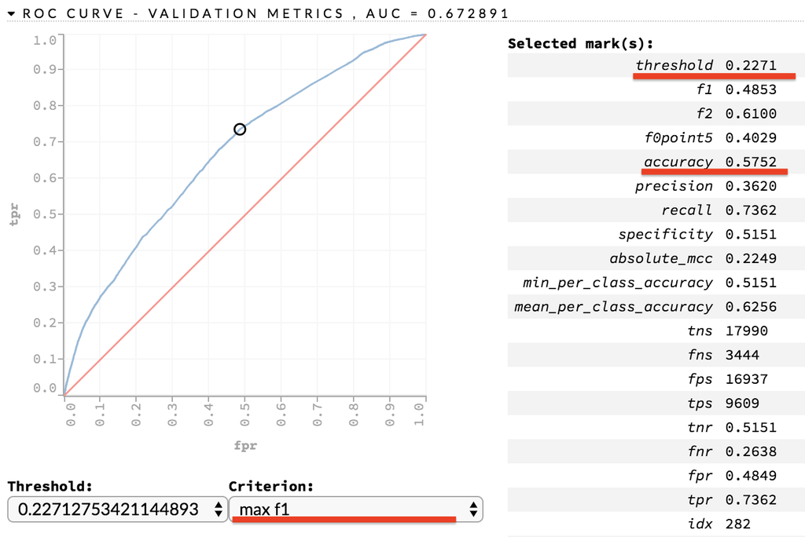

```python
from PIL import Image
Image.open("image_1.PNG")
```

1. (1 pt.) What is the cumulative lift for the model at the 10th decile?

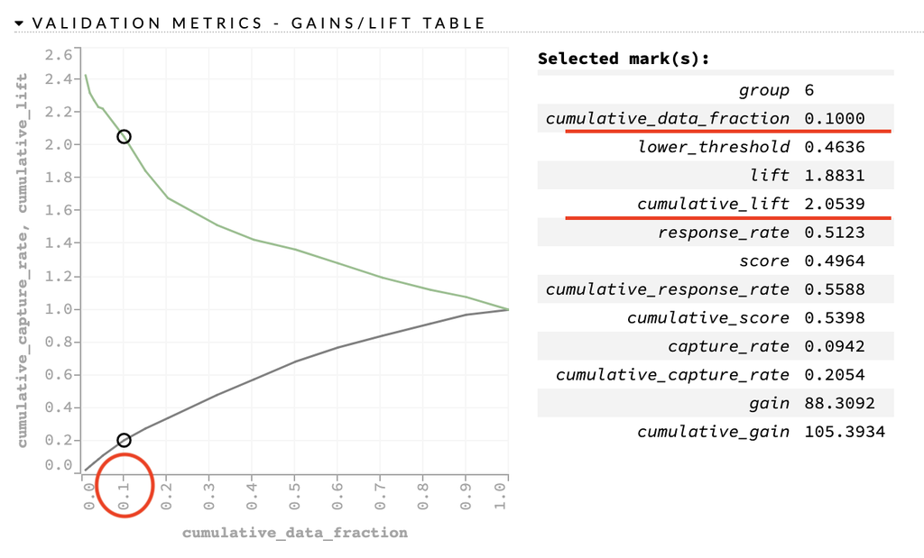

```python
# regression.gains_lift(xval = True)
Image.open("image_2.PNG")
```

1. (1 pt.) What offer day of the week is most positively associated with becoming a repeat shopper?

Answer: `Saterday` is most positively associated with becoming a repeat shopper.

1. (2 pts.) What is the interpretation of the coefficient associated with a customer having bought the exact item in the past?

Answer: Holding all other variables constant, a customer having bought the exact item in the past changes the odds of the customer becoming a repeat shopper occurring by a factor of exp(0.2153) = 1.2402 over the customer who did not buy the exact item.

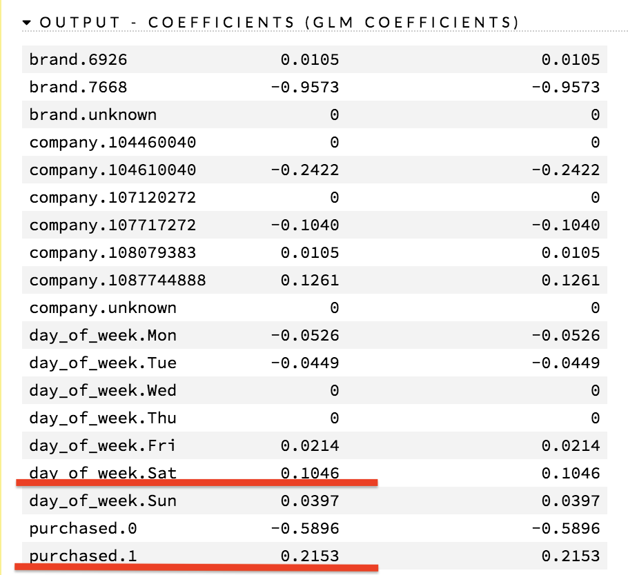

```python
Image.open("image_3.PNG")
```

1. (1 pt.) What is the probability for ID 13584134 in the score set to become a repeat shopper according to your model.

Answer: 0.10956

```python
regression.predict(score_hf[score_hf['id'] == 13584134])
```

```
glm prediction progress: |████████████████████████████████████████████████| 100%
```

| predict | p0 | p1 |
| --- | --- | --- |
| 0 | 0.89044 | 0.10956 |

Bonus: What potential modeling problem did our data preprocessing in assignment 1 cause?

We do not consider outliers in the data during our data preprocessing progress, which may cause biased models and biased, inaccurate results.

```python
h2o.cluster().shutdown(prompt = False)
```

```
H2O session _sid_9b9d closed.
```

To receive full credit for this assignment, turn in your group’s answers to these questions, your R or Python script/notebook (1 pt.), and your POJO (1 pt.) in one zipped file to Blackboard.